# Spotify Data

12. 12. 2023

## Introduction

## DATA

- Most Streamed Spotify Songs 2023
- Kaggle — Nidula Elgiriyewithana
- numeric variable — streams

## DESCRIPTION OF VARIABLES

- PLAYLISTS – appearance of songs in different platforms’ playlists
- CHARTS – appearance of songs in different platforms’ charts
- MUSICAL ATTRIBUTES – beats per minute, key and mode of the song
- ARTIST INFORMATION – name of artist(s), number of artists contributing to songs
- SONG INFORMATION – track name, day, month and year of release
- OTHERS – danceability, acousticness, liveness, …

## SUMMARY

```r
summary(spotify_data[,1:8])
```

```
##   track_name        artists_name        artist_count   released_year
##  Length:829         Length:829         Min.   :1.000   Min.   :1930
##  Class :character   Class :character   1st Qu.:1.000   1st Qu.:2021
##  Mode  :character   Mode  :character   Median :1.000   Median :2022
##                                        Mean   :1.581   Mean   :2019
##                                        3rd Qu.:2.000   3rd Qu.:2022
##                                        Max.   :8.000   Max.   :2023
##  released_month    released_day   in_spotify_playlists in_spotify_charts
##  Min.   : 1.000   Min.   : 1.00   Min.   :   31        Min.   :  0.00
##  1st Qu.: 3.000   1st Qu.: 6.00   1st Qu.:  801        1st Qu.:  0.00
##  Median : 6.000   Median :13.00   Median : 1788        Median :  2.00
##  Mean   : 6.154   Mean   :14.11   Mean   : 3116        Mean   : 10.82
##  3rd Qu.: 9.000   3rd Qu.:22.00   3rd Qu.: 3879        3rd Qu.: 15.00
##  Max.   :12.000   Max.   :31.00   Max.   :29499        Max.   :147.00
```

```r
summary(spotify_data[,9:16])
```

```
##     streams          in_apple_playlists in_apple_charts  in_deezer_playlists
##  Min.   :2.762e+03   Min.   :  0.00     Min.   :  0.00   Min.   :  0.00
##  1st Qu.:1.304e+08   1st Qu.: 11.00     1st Qu.:  6.00   1st Qu.: 12.00
##  Median :2.451e+08   Median : 27.00     Median : 30.00   Median : 32.00
##  Mean   :3.738e+08   Mean   : 49.69     Mean   : 47.15   Mean   : 96.75
##  3rd Qu.:4.817e+08   3rd Qu.: 68.00     3rd Qu.: 80.00   3rd Qu.: 99.00
##  Max.   :2.808e+09   Max.   :492.00     Max.   :275.00   Max.   :974.00
##  in_deezer_charts in_shazam_charts      bpm          key
##  Min.   : 0.000   Min.   :  0.00   Min.   : 65   Length:829
##  1st Qu.: 0.000   1st Qu.:  0.00   1st Qu.:100   Class :character
##  Median : 0.000   Median :  2.00   Median :121   Mode  :character
##  Mean   : 2.341   Mean   : 48.71   Mean   :123
##  3rd Qu.: 1.000   3rd Qu.: 33.00   3rd Qu.:142
##  Max.   :45.000   Max.   :953.00   Max.   :206
```

```r
summary(spotify_data[,17:24])
```

```
##      mode            danceability     valence          energy
##  Length:829         Min.   :23.0   Min.   : 4.00   Min.   :14.00
##  Class :character   1st Qu.:58.0   1st Qu.:32.00   1st Qu.:53.00
##  Mode  :character   Median :70.0   Median :51.00   Median :65.00
##                     Mean   :67.4   Mean   :51.37   Mean   :64.24
##                     3rd Qu.:78.0   3rd Qu.:70.00   3rd Qu.:77.00
##                     Max.   :96.0   Max.   :97.00   Max.   :97.00
##   acousticness   instrumentalness    liveness      speechiness
##  Min.   : 0.00   Min.   : 0.000   Min.   : 3.00   Min.   : 2.00
##  1st Qu.: 6.00   1st Qu.: 0.000   1st Qu.:10.00   1st Qu.: 4.00
##  Median :18.00   Median : 0.000   Median :12.00   Median : 6.00
##  Mean   :27.07   Mean   : 1.654   Mean   :18.33   Mean   :10.43
##  3rd Qu.:42.00   3rd Qu.: 0.000   3rd Qu.:23.00   3rd Qu.:12.00
##  Max.   :97.00   Max.   :91.000   Max.   :97.00   Max.   :64.00
```

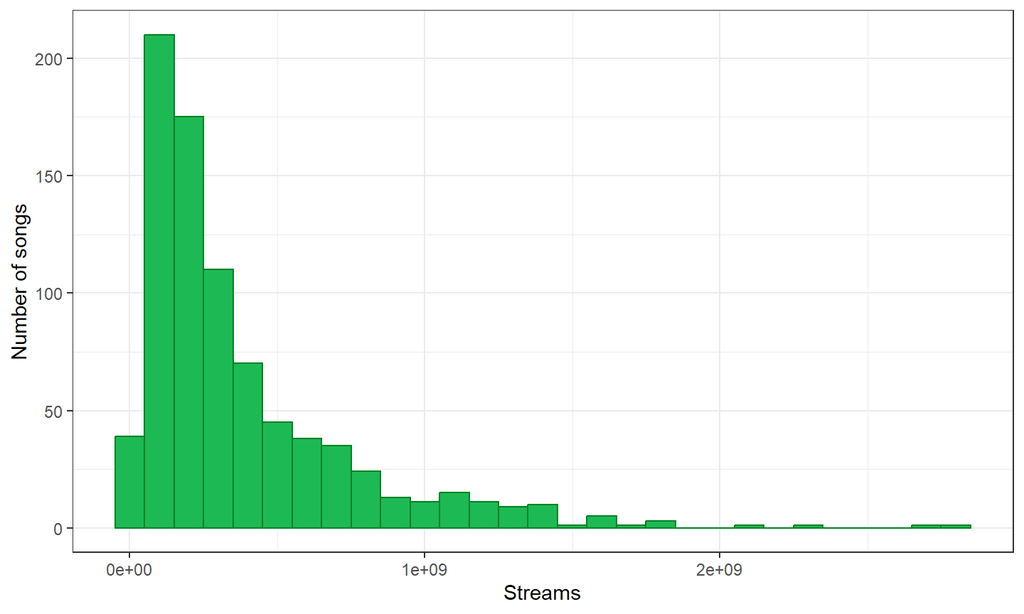

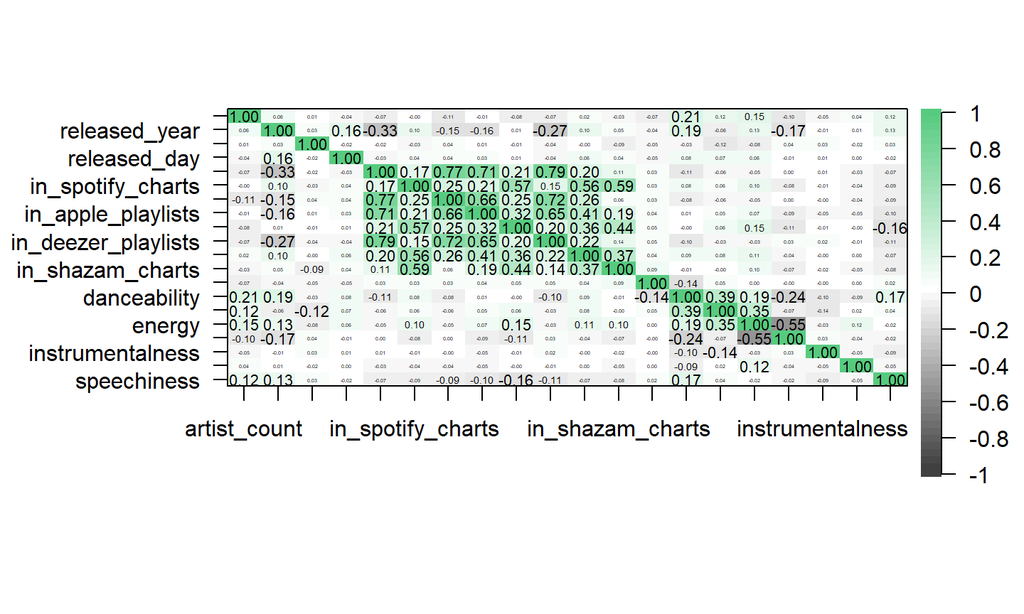

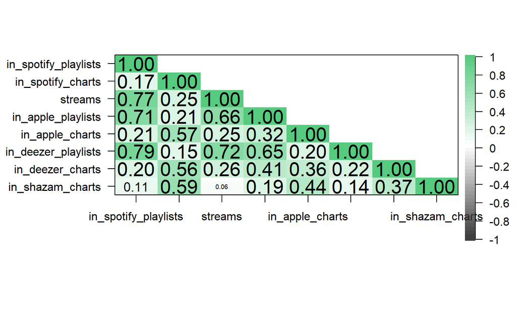

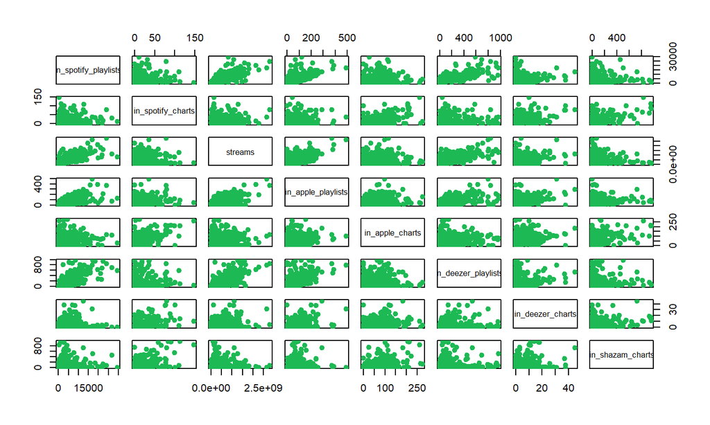

## SPOTIFY/APPLE/DEEZER PLAYLISTS

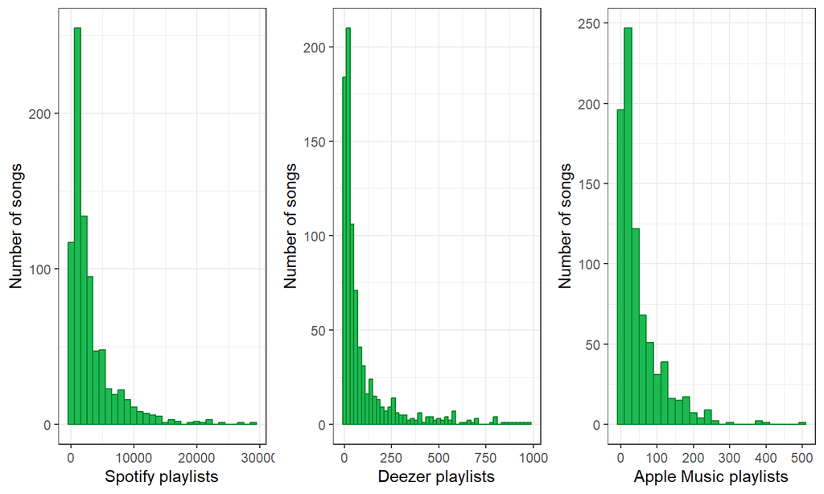

## SPOTIFY/APPLE/DEEZER CHARTS

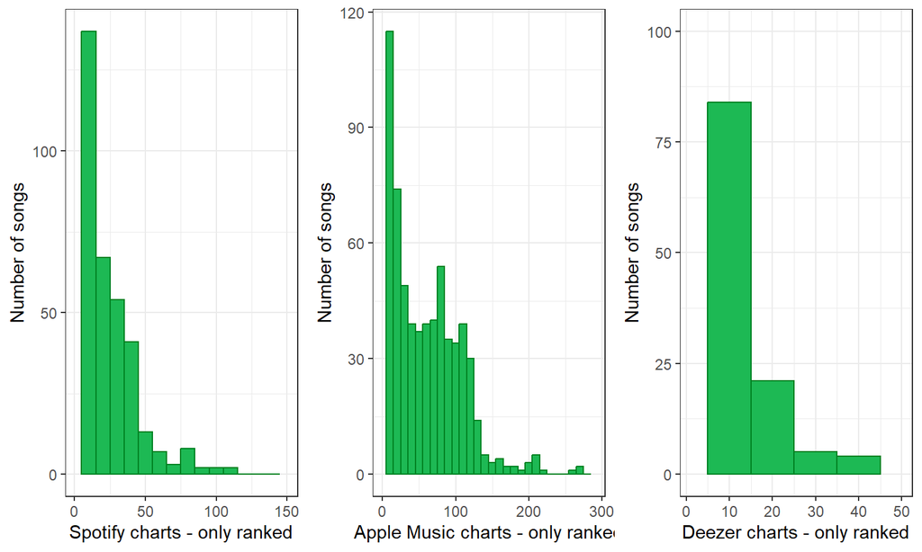

## ARTISTS

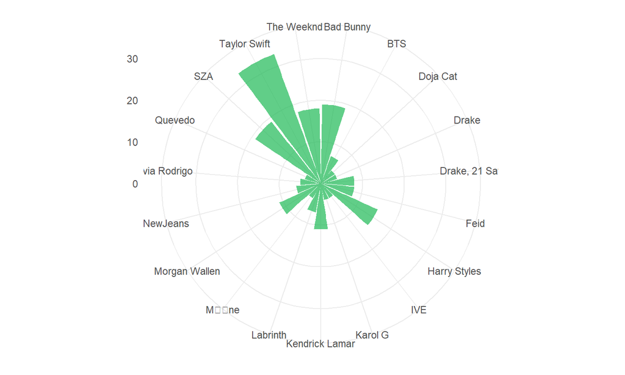

LUCČIN FINÁLNÍ KÓD

#### Modely do projektu

model3a <- lm(streams ~ in_spotify_charts*in_apple_charts + in_apple_charts* in_deezer_charts + in_spotify_charts *in_deezer_charts + in_spotify_charts* in_deezer_charts*in_apple_charts, data = spotify_data ) summary(model3a) # 0.1325 AIC(model3a) #34954.95 BIC(model3a) #34997.43

model3b <- lm(streams ~ in_spotify_playlists*in_spotify_charts + in_apple_playlists* in_apple_charts + in_deezer_charts *in_deezer_playlists, data = spotify_data) summary(model3b) #0.6513 AIC(model3b) # 34201.31 BIC(model3b) # 34253.23

model6 <- lm(streams ~ in_spotify_playlists*in_apple_playlists + in_apple_playlists* in_deezer_playlists + in_spotify_playlists *in_deezer_playlists + in_spotify_playlists* in_deezer_playlists*in_apple_playlists, data = spotify_data ) summary(model6) #0.6776# AIC(model6) #34134.38 BIC(model6) #34176.86 shapiro.test(sample(rstandard(model6), size=50)) #0.001118

model8 <- lm(streams ~ in_spotify_playlists*in_spotify_charts + in_apple_playlists* in_apple_charts + in_deezer_charts *in_deezer_playlists + in_spotify_playlists*in_apple_playlists + in_apple_playlists* in_deezer_playlists + in_spotify_playlists *in_deezer_playlists + in_spotify_playlists* in_deezer_playlists*in_apple_playlists, data = spotify_data ) summary(model8) #0.6921# anova(model8) AIC(model8) #34102.16 BIC(model8) #34172.96 shapiro.test(sample(rstandard(model8), size=50)) #0.001466

model9 <- lm(streams ~ in_spotify_playlists* in_deezer_playlists*in_apple_playlists + in_spotify_playlists* in_deezer_playlists+ in_apple_playlists* in_apple_charts + in_spotify_playlists*in_spotify_charts + in_apple_playlists +in_spotify_playlists+in_spotify_charts, data = spotify_data) summary(model9)#0.6922# anova(model9) AIC(model9)#34100.04 BIC(model9)#34161.4 shapiro.test(sample(rstandard(model9), size=50)) #0.0006929

model11 <- lm(streams ~ in_spotify_playlists* in_deezer_playlists*in_apple_playlists + in_spotify_playlists* in_deezer_playlists+ in_spotify_playlists*in_spotify_charts + in_apple_playlists +in_spotify_playlists+in_spotify_charts, data = spotify_data) summary(model11)#0.6922 anova(model11) AIC(model11)#34097.86 BIC(model11)#34149.11 shapiro.test(sample(rstandard(model11), size=50)) #3.079e-05